# ESM206 Final

Teresa Fukuda

12/7/2018

### Task 1. Climate Change Opinions

1. I chose to create a multiple linear regression model because the relationships between the input variables and the output (happening) appear to be somewhat linear, independent, and there is more than one explanatory variable that I think contributes to the outcome of the output variable.

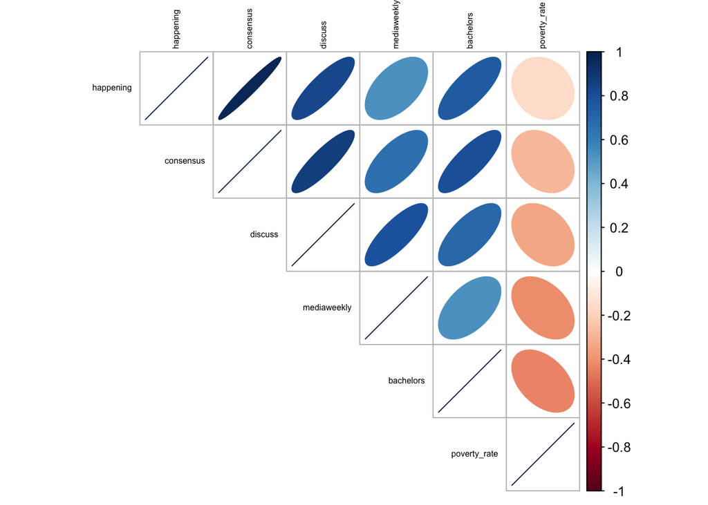

3. **Table 1.** Multiple linear regression model of opinions on climate change. Variables are described in terms of percentage that agrees with the statements. Data source: [Yale Climate Opinion Maps](http://climatecommunication.yale.edu/%20visualizations-data/ycom-us-2018/?est=happening&type=value&geo=county) and US Census Bureau

|  | *Dependent variable:* |
| --- | --- |
|  | Agrees that climate change is happening |
| Discuss global warming | 0.836*** |
|  | (0.132) |
| Hears about global warming in the media weekly | -0.318* |
|  | (0.160) |
| Have attained a Bachelors degree | 0.342*** |
|  | (0.062) |
| Poverty rate | 0.288*** |
|  | (0.096) |
| Lives in a state with coastline | 2.217*** |
|  | (0.560) |
| Constant | 30.608*** |
|  | (3.226) |
| Observations | 51 |
| R<sup>2</sup> | 0.881 |
| Adjusted R<sup>2</sup> | 0.868 |
| Residual Std. Error | 1.805 (df = 45) |
| F Statistic | 66.905*** (df = 5; 45) |
| *Note:* | p<0.1; p<0.05; p<0.01 |